# Time-varying spatial data; raster and vector data cubes; recap on ECZ Geospatial modelling

Edzer Pebesma

2/16/2022

We will work with the data provide by the course management.

## surface temperature

```r
library(stars)
load("EU_COSMOLEPS_airTemperature_mean24h.RData")
DF = DF[,-2] # remove second column, which duplicates the first
x = st_as_stars(list(DF = t(as.matrix(DF)))) |>
    st_set_dimensions(1, st_geometry(Psf_in), name = "geometry") |>
    st_set_dimensions(2, D, name = "time")
x
```

```
## stars object with 2 dimensions and 1 attribute
## attribute(s):
##          Min.  1st Qu.   Median     Mean  3rd Qu.     Max.
## DF  -8.488512 7.642181 11.02402 11.70991 14.90923 31.96777
## dimension(s):
##          from  to offset delta refsys point
## geometry    1 370     NA    NA WGS 84  TRUE
## time        1 255     NA    NA   Date    NA
##                                                           values
## geometry POINT (13.78425 41.20805),...,POINT (15.78641 40.26846)
## time                                   2020-10-21,...,2021-07-06
```

We see that this is a 2-D data cube, with dimensions

- time
- geometry

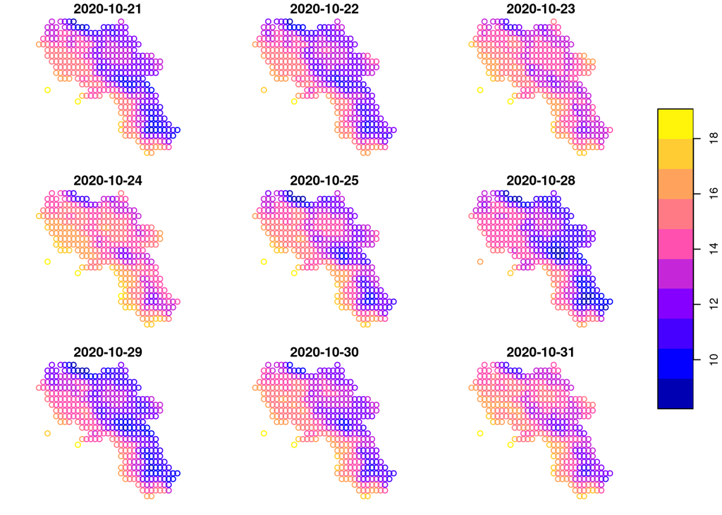

```r
plot(x[,,1:9], breaks = "equal")
```

we can convert this to a multiple time series object by

```r
library(xts)
```

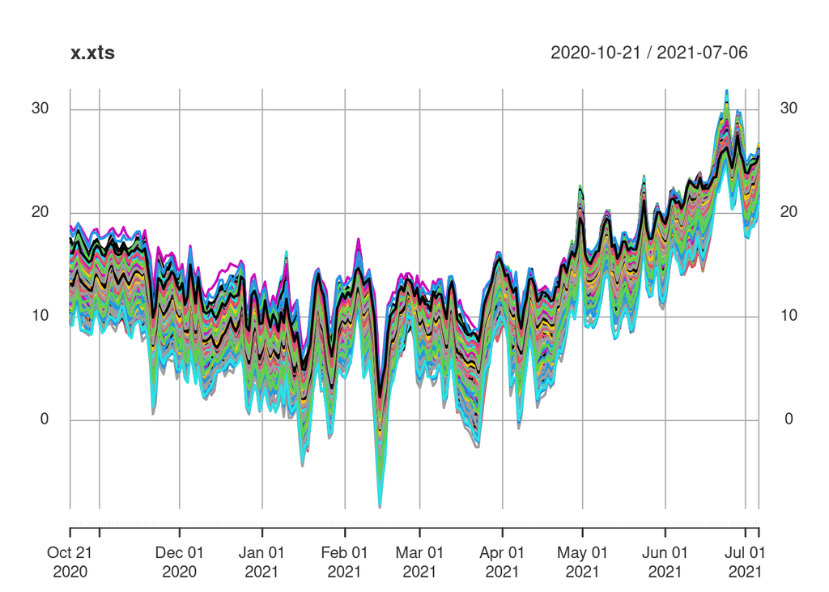

```r
x.xts = as.xts(x)
plot(x.xts)
```

- we distribute time over multiple columns (“wide form”), or
- we do **not** distribute time over columns (“long form”)

The long form:

```r
st_as_sf(x, long = TRUE)
```

```
## Simple feature collection with 94350 features and 2 fields
## Geometry type: POINT
## Dimension:     XY
## Bounding box:  xmin: 13.78425 ymin: 40.0179 xmax: 15.78641 ymax: 41.45861
## Geodetic CRS:  WGS 84
## First 10 features:
##          time       DF                  geometry
## 1  2020-10-21 16.16836 POINT (13.78425 41.20805)
## 2  2020-10-21 15.57505 POINT (13.84682 41.20805)
## 3  2020-10-21 14.69304 POINT (13.84682 41.27069)
## 4  2020-10-21 18.43196 POINT (13.90939 40.70694)
## 5  2020-10-21 15.78125 POINT (13.90939 41.08277)
## 6  2020-10-21 15.44141 POINT (13.90939 41.14541)
## 7  2020-10-21 14.91565 POINT (13.90939 41.20805)
## 8  2020-10-21 14.06367 POINT (13.90939 41.27069)
## 9  2020-10-21 13.29495 POINT (13.90939 41.33333)
## 10 2020-10-21 13.23079 POINT (13.90939 41.39597)
```

The wide form:

```r
x.sf = st_as_sf(x)
dim(x.sf)
```

```
## [1] 370 256
```

```r
x.sf[,1:3] # print only the first three
```

```
## Simple feature collection with 370 features and 3 fields
## Geometry type: POINT
## Dimension:     XY
## Bounding box:  xmin: 13.78425 ymin: 40.0179 xmax: 15.78641 ymax: 41.45861
## Geodetic CRS:  WGS 84
## First 10 features:
##         2020-10-21 2020-10-22 2020-10-23                  geometry
## node_1    16.16836   16.15209   17.11279 POINT (13.78425 41.20805)
## node_2    15.57505   15.52850   16.31924 POINT (13.84682 41.20805)
## node_3    14.69304   14.64489   15.56343 POINT (13.84682 41.27069)
## node_4    18.43196   17.76896   18.27954 POINT (13.90939 40.70694)
## node_5    15.78125   15.99572   16.46270 POINT (13.90939 41.08277)
## node_6    15.44141   15.48009   15.97278 POINT (13.90939 41.14541)
## node_7    14.91565   14.85490   15.43386 POINT (13.90939 41.20805)
## node_8    14.06367   13.81837   14.63977 POINT (13.90939 41.27069)
## node_9    13.29495   13.04213   14.07905 POINT (13.90939 41.33333)
## node_10   13.23079   13.10160   14.17478 POINT (13.90939 41.39597)
```

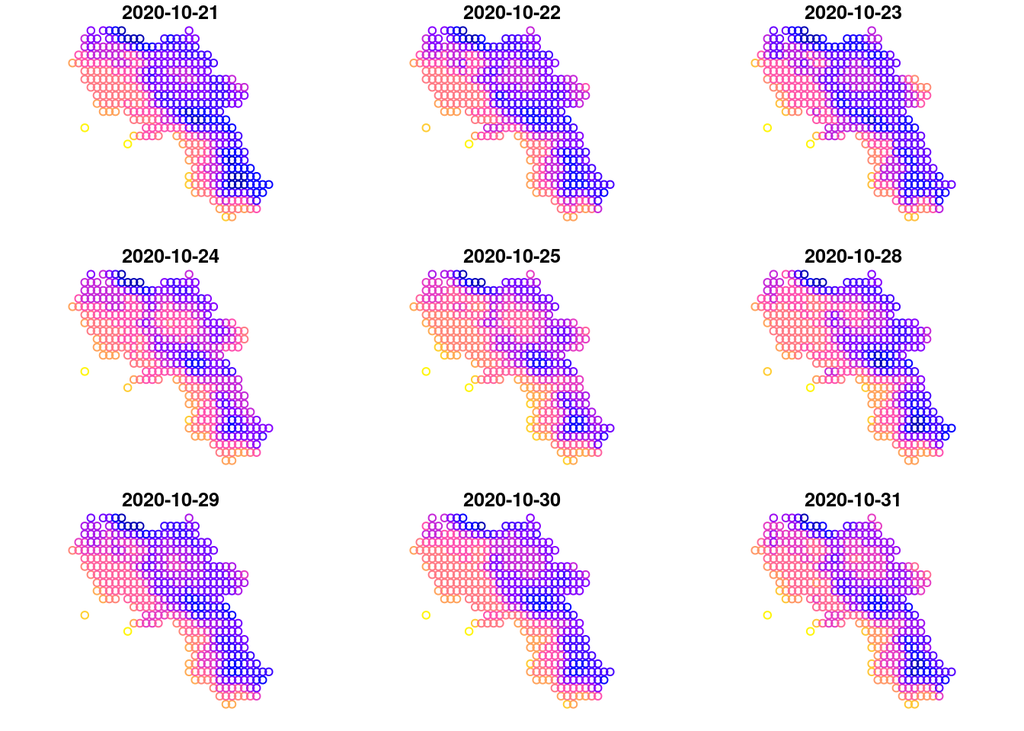

```r
plot(x.sf) # plots by default first few attributes
```

Since the points of this data cube are on a regular raster, let us try to make a raster cube of it.

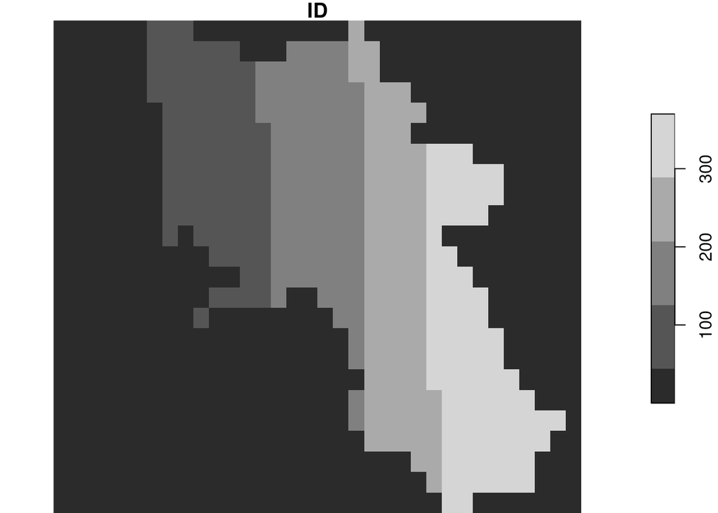

```r
r = st_rasterize(Psf_in)
plot(r)
```

This raster maps the points one-to-one to a raster, with zero values where there are no points. This can be seen from

```r
as.vector(r[[1]]) |> # all values in a vector
  unique() |> # all unique values
  sort() # sorted
```

```
##   [1]   0   1   2   3   4   5   6   7   8   9  10  11  12  13  14  15  16  17
##  [19]  18  19  20  21  22  23  24  25  26  27  28  29  30  31  32  33  34  35
##  [37]  36  37  38  39  40  41  42  43  44  45  46  47  48  49  50  51  52  53
##  [55]  54  55  56  57  58  59  60  61  62  63  64  65  66  67  68  69  70  71
##  [73]  72  73  74  75  76  77  78  79  80  81  82  83  84  85  86  87  88  89
##  [91]  90  91  92  93  94  95  96  97  98  99 100 101 102 103 104 105 106 107
## [109] 108 109 110 111 112 113 114 115 116 117 118 119 120 121 122 123 124 125
## [127] 126 127 128 129 130 131 132 133 134 135 136 137 138 139 140 141 142 143
## [145] 144 145 146 147 148 149 150 151 152 153 154 155 156 157 158 159 160 161
## [163] 162 163 164 165 166 167 168 169 170 171 172 173 174 175 176 177 178 179
## [181] 180 181 182 183 184 185 186 187 188 189 190 191 192 193 194 195 196 197
## [199] 198 199 200 201 202 203 204 205 206 207 208 209 210 211 212 213 214 215
## [217] 216 217 218 219 220 221 222 223 224 225 226 227 228 229 230 231 232 233
## [235] 234 235 236 237 238 239 240 241 242 243 244 245 246 247 248 249 250 251
## [253] 252 253 254 255 256 257 258 259 260 261 262 263 264 265 266 267 268 269
## [271] 270 271 272 273 274 275 276 277 278 279 280 281 282 283 284 285 286 287
## [289] 288 289 290 291 292 293 294 295 296 297 298 299 300 301 302 303 304 305
## [307] 306 307 308 309 310 311 312 313 314 315 316 317 318 319 320 321 322 323
## [325] 324 325 326 327 328 329 330 331 332 333 334 335 336 337 338 339 340 341
## [343] 342 343 344 345 346 347 348 349 350 351 352 353 354 355 356 357 358 359
## [361] 360 361 362 363 364 365 366 367 368 369 370
```

```r
as.vector(r[[1]]) |> # all values in a vector
  unique() |> # all unique values
  length() # includes 0 values
```

```
## [1] 371
```

```r
dim(x) # 371-1 geometries
```

```
## geometry     time
##      370      255
```

Now we need to match the 370 geometries to the raster values 1-370. First we set the zero values to `NA`:

```r
r[r == 0] = NA
r
```

```
## stars object with 2 dimensions and 1 attribute
## attribute(s):
##     Min. 1st Qu. Median  Mean 3rd Qu. Max. NA's
## ID     1   93.25  185.5 185.5  277.75  370  446
## dimension(s):
##   from to  offset      delta refsys point values x/y
## x    1 34  13.753  0.0625674 WGS 84 FALSE   NULL [x]
## y    1 24 41.4899 -0.0626398 WGS 84 FALSE   NULL [y]
```

```r
DF.r = t(as.matrix(DF))[as.vector(r[[1]]),]
dim(DF.r)
```

```
## [1] 816 255
```

```r
dim(DF.r) = c(34, 24, 255) # make it a 3D array
DF.st = st_as_stars(list(temp = DF.r))
```

We need to create a dimensions object for this matrix:

```r
rd = st_dimensions(r) # x&y
rd[[3]] = st_dimensions(x)[[2]] # time
names(rd)[3] = "time"
rd
```

```
##      from  to  offset      delta refsys point                    values x/y
## x       1  34  13.753  0.0625674 WGS 84 FALSE                      NULL [x]
## y       1  24 41.4899 -0.0626398 WGS 84 FALSE                      NULL [y]
## time    1 255      NA         NA   Date    NA 2020-10-21,...,2021-07-06
```

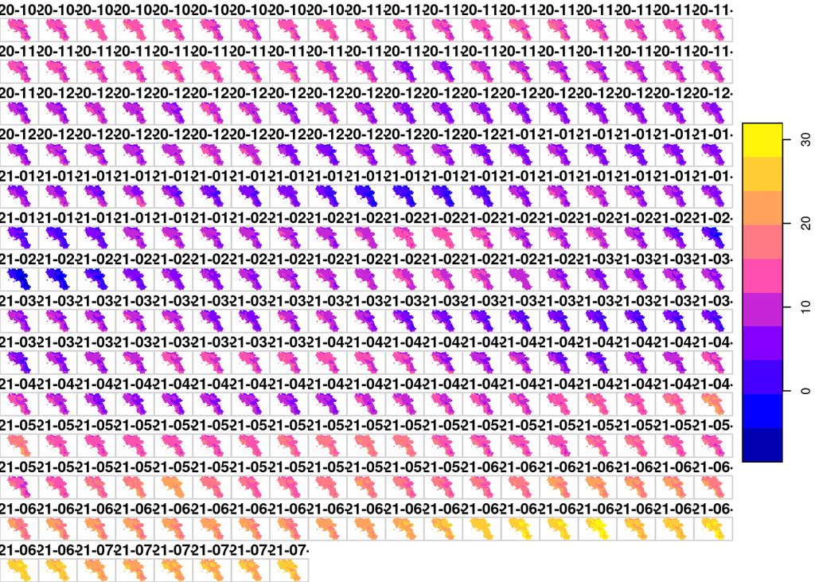

```r
st_dimensions(DF.st) = rd
plot(DF.st, breaks = "equal", col = sf.colors())
```

We can also plot fewer, e.g. every 10-th day, and add an outline of the region

```r
sel = seq(1, 255, by = 10)
sel
```

```
##  [1]   1  11  21  31  41  51  61  71  81  91 101 111 121 131 141 151 161 171 181
## [20] 191 201 211 221 231 241 251
```

```r
outline = st_read("roi_ca_geom.geojson")
```

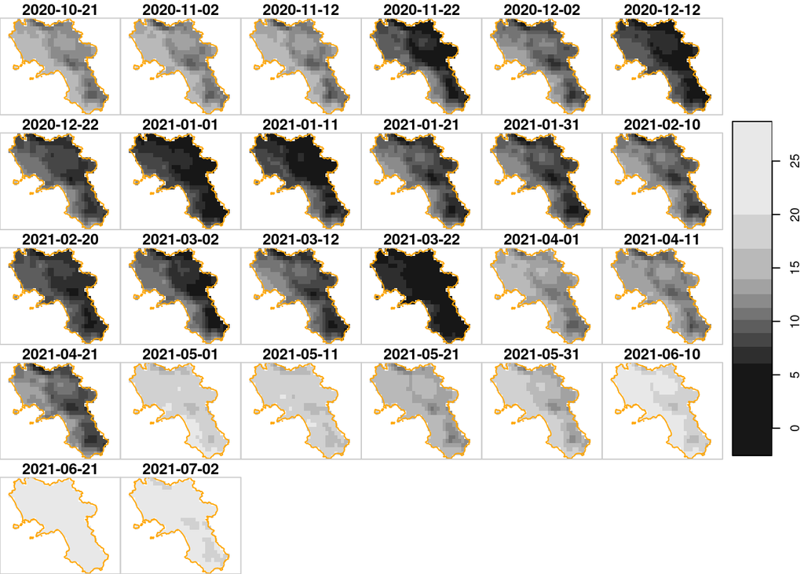

```r
f = function() plot(st_geometry(outline), add=TRUE, border = "orange")
plot(DF.st[,,,sel], hook = f)
```

We can do something similar with `ggplot2`:

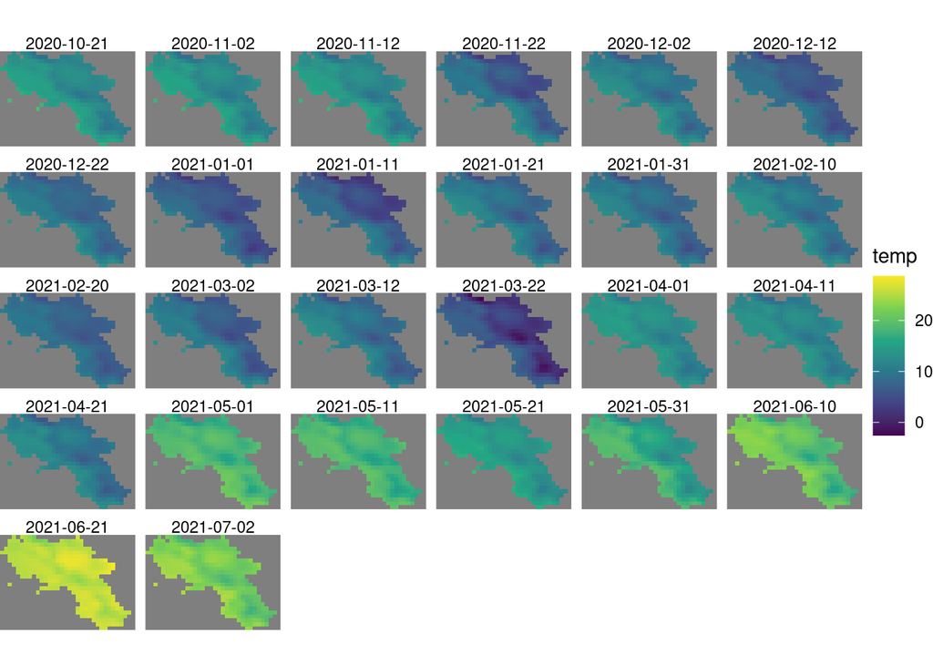

```r
library(ggplot2)
ggplot() +
        geom_stars(data = DF.st[,,,sel]) +
        facet_wrap(~time) + coord_equal() +
        theme_void() +
        scale_x_discrete(expand = c(0,0)) +
        scale_y_discrete(expand = c(0,0)) +
        scale_fill_viridis_c()
```

## Analysis

We can plot a single time series, e.g. by picking the row and column

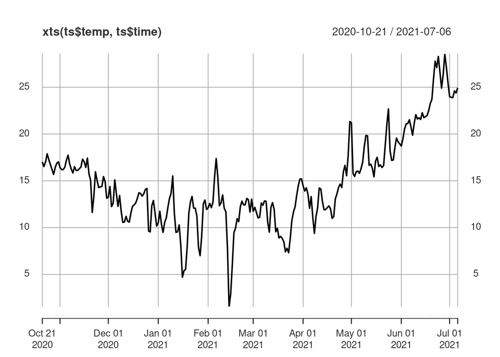

```r
ts = DF.st[,20,20] |> st_as_sf(long = TRUE)
xts(ts$temp, ts$time) |> plot()
```

We can also query a (spatial) point using `st_extract()`:

```r
pt = st_as_sfc("POINT (14.97303 40.26846)", crs = st_crs(DF.st))
st_extract(DF.st, pt)
```

```
## stars object with 2 dimensions and 1 attribute
## attribute(s):
##           Min.  1st Qu.   Median     Mean  3rd Qu.     Max.
## temp  1.554506 11.74433 13.65077 14.68995 16.94355 28.56132
## dimension(s):
##          from  to offset delta refsys point                    values
## geometry    1   1     NA    NA WGS 84  TRUE    POINT (14.973 40.2685)
## time        1 255     NA    NA   Date    NA 2020-10-21,...,2021-07-06
```

```r
st_extract(DF.st, pt) |> st_as_sf(long = TRUE)
```

```
## Simple feature collection with 255 features and 2 fields
## Geometry type: POINT
## Dimension:     XY
## Bounding box:  xmin: 14.97303 ymin: 40.26846 xmax: 14.97303 ymax: 40.26846
## Geodetic CRS:  WGS 84
## First 10 features:
##          time     temp                  geometry
## 1  2020-10-21 17.02534 POINT (14.97303 40.26846)
## 2  2020-10-22 16.52435 POINT (14.97303 40.26846)
## 3  2020-10-23 17.02175 POINT (14.97303 40.26846)
## 4  2020-10-24 17.88448 POINT (14.97303 40.26846)
## 5  2020-10-25 17.27534 POINT (14.97303 40.26846)
## 6  2020-10-28 15.68236 POINT (14.97303 40.26846)
## 7  2020-10-29 16.43141 POINT (14.97303 40.26846)
## 8  2020-10-30 16.88123 POINT (14.97303 40.26846)
## 9  2020-10-31 17.03182 POINT (14.97303 40.26846)
## 10 2020-11-01 16.41521 POINT (14.97303 40.26846)
```

We can make a time slice, e.g. for the 100-th time index by

```r
DF.st[,,,100]
```

```
## stars object with 3 dimensions and 1 attribute
## attribute(s):
##           Min.  1st Qu.   Median     Mean  3rd Qu.     Max. NA's
## temp  4.852757 8.104552 9.406712 9.458755 10.84571 13.95744  446
## dimension(s):
##      from  to  offset      delta refsys point     values x/y
## x       1  34  13.753  0.0625674 WGS 84 FALSE       NULL [x]
## y       1  24 41.4899 -0.0626398 WGS 84 FALSE       NULL [y]
## time  100 100      NA         NA   Date    NA 2021-01-30
```

```r
DF.st[,,,100] |> adrop()
```

```
## stars object with 2 dimensions and 1 attribute
## attribute(s):
##           Min.  1st Qu.   Median     Mean  3rd Qu.     Max. NA's
## temp  4.852757 8.104552 9.406712 9.458755 10.84571 13.95744  446
## dimension(s):
##   from to  offset      delta refsys point values x/y
## x    1 34  13.753  0.0625674 WGS 84 FALSE   NULL [x]
## y    1 24 41.4899 -0.0626398 WGS 84 FALSE   NULL [y]
```

We could do various aggregations, e.g. compute the mean temparture

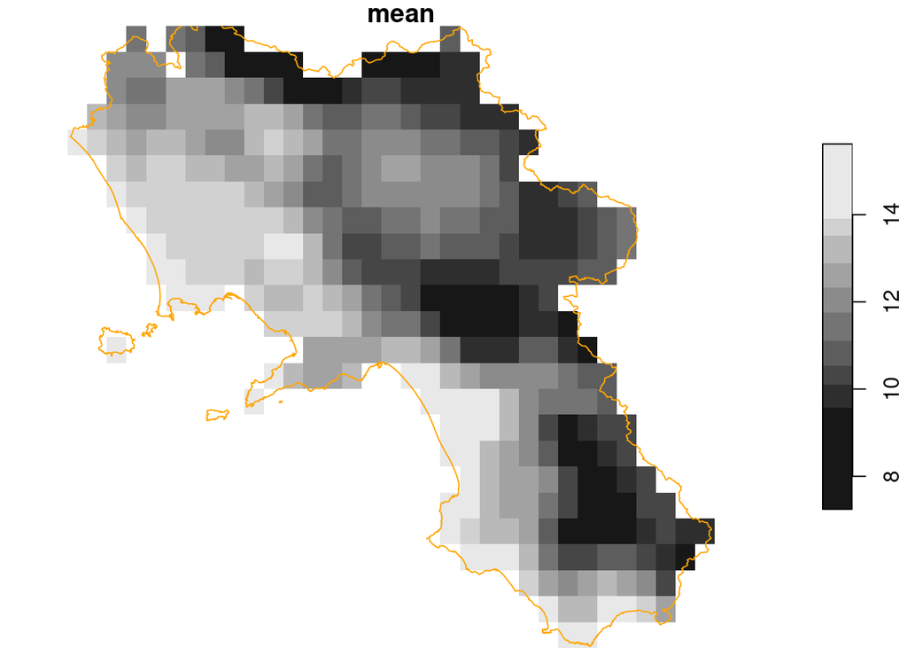

```r
DF.m = st_apply(DF.st, c("x", "y"), mean)
plot(DF.m, reset = FALSE)
st_geometry(outline) |> plot(border = "orange", add = TRUE)
```

or find the day with the highest daily mean temperature

```r
library(dplyr) # select
mx = function(x) ifelse(all(is.na(x)), NA_real_, which.max(x))
DF.m = st_apply(DF.st, c("x", "y"), mx)
DF.m
```

```
## stars object with 2 dimensions and 1 attribute
## attribute(s):
##     Min. 1st Qu. Median     Mean 3rd Qu. Max. NA's
## mx   244     244    244 244.4459     244  247  446
## dimension(s):
##   from to  offset      delta refsys point values x/y
## x    1 34  13.753  0.0625674 WGS 84 FALSE   NULL [x]
## y    1 24 41.4899 -0.0626398 WGS 84 FALSE   NULL [y]
```

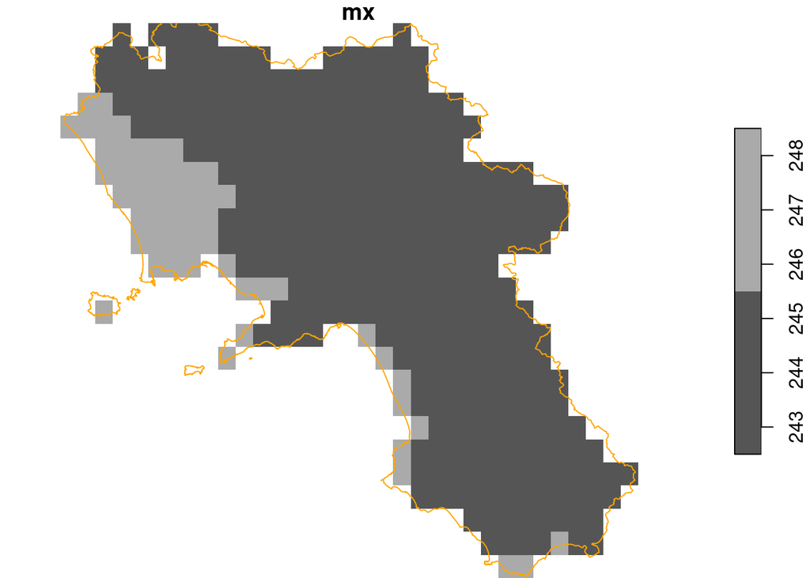

```r
plot(DF.m, reset = FALSE)
st_geometry(outline) |> plot(border = "orange", add = TRUE)
```

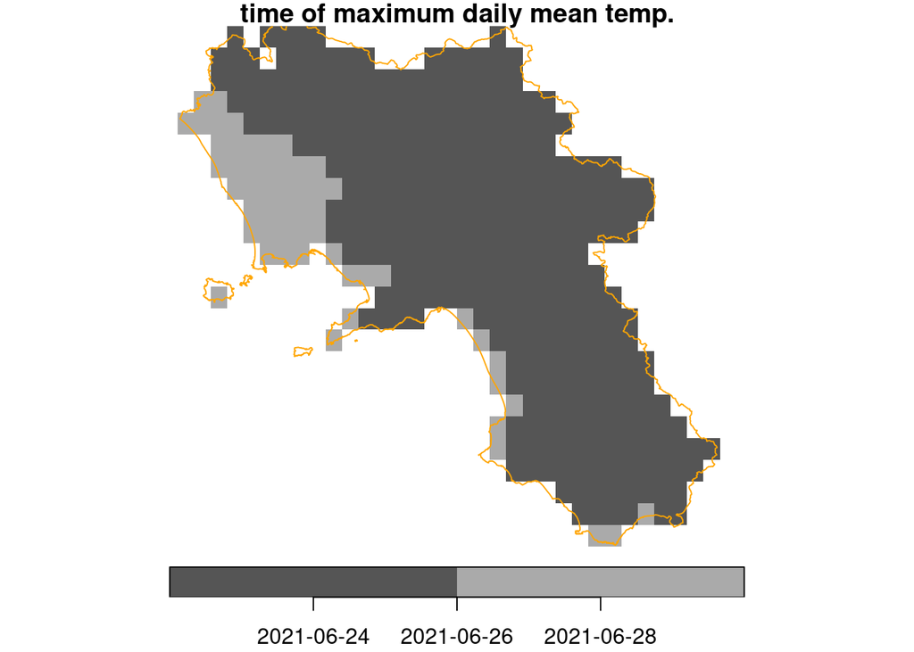

```r
DF.m %>%
  mutate(when = st_get_dimension_values(DF.st, "time")[.$mx]) %>%
  select(when) %>%
  plot(key.pos = 1, main = "time of maximum daily mean temp.", reset = FALSE)
st_geometry(outline) |> plot(border = "orange", add = TRUE)
```

There are only two values in the map:

```r
(u = unique(as.vector(DF.m[[1]])))
```

```
## [1]  NA 244 247
```

```r
st_get_dimension_values(DF.st, "time")[u]
```

```
## [1] NA           "2021-06-24" "2021-06-28"
```

## Exercises

1. load the .Rmd corresponding to these slides, download the dataset(s), and run the analysis.
2. rerun the analysis but now with the maximum temperatures (other dataset to be loaded)
3. extract the temperature time series data at the locations where the soil samples were taken (dataset of day 7)
4. compute the maximum temperature, over the whole time series, over the area where bulk density predictions (kriged values) exceed 1.1.